# 1. Linear regression

Robert Lohne

13 6 2021

# 1. What *is* Linear regression?

Linear regression is a simple method for statistical learning. In it’s simplest form (aptly named simple regression), it deals with a single explanatory variable (sometimes called the predictor), denoted $X$ and the dependent variable (sometimes referred to as the outcome variable), denoted $Y$. The assumption is that there is a relationship between the two, and that $X$ can be used to predict the value of $Y$. This is usually expressed as $Y = f(X) + \epsilon$ . $f$ is in this case a function of X, and $epsilon$ (greek letter epsilon) is a random error term, that is independent of $X$ and has a mean zero. As an example, consider the following assumption: the miles per gallon (mpg) feature of a car has a relationship with it’s weight, and we assume that the lower the weight, the higher the mpg.

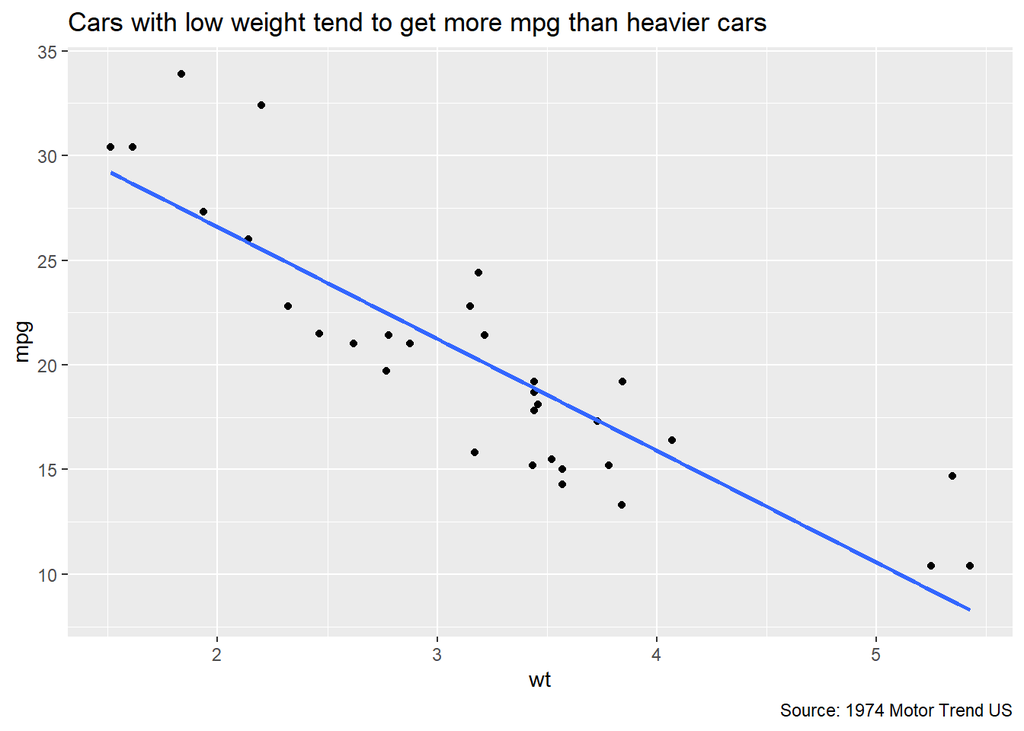

In a traditional regression analysis the variance in $Y$ explained by $X$ is denoted $R^2$. This is scored between 0 and 100 %. 0, or a $R^2$ score of 0.00 means 0 % of the variance is explained by the model, and 1 (100 %) means that all the variance is explained by the model. OK - so what is a “good” value of $R^2$? Well, this is where it gets complicated. It depends on the field, the context and the variables among other things.